# ml-challenge-stage-emobot-zaoug-imad

**Geospatial Change Detection Challenge: Leveraging Machine Learning for Urban Transformation**

*Author* : Imad ZAOUG

Outline:

1. Data Exploration and Preprocessing
2. Data Analysis and Feature Engineering
3. Model Testing
4. Model Comparison
5. Conclusion

**Data Exploration and Preprocessing**

```python
import geopandas as gpd
import pandas as pd
from sklearn.preprocessing import LabelEncoder
import numpy as np


from sklearn.neighbors import KNeighborsClassifier

from sklearn.metrics import accuracy_score

change_type_map = {'Demolition': 0, 'Road': 1, 'Residential': 2, 'Commercial': 3, 'Industrial': 4,
       'Mega Projects': 5}
```

We initiate the process by parsing the GeoJSON files using Geopandas.

```python
## Read csvs

train_df = gpd.read_file('/kaggle/input/emobot-test/train.geojson', index_col=0)
```

```python
test_df = gpd.read_file('/kaggle/input/emobot-test/test.geojson', index_col=0)
```

```python
train_df
```

|  | index | change_type | change_status_date1 | change_status_date2 | change_status_date3 | change_status_date4 | change_status_date5 | date1 | date2 | date3 | date4 | date5 | urban_types | geography_types | geometry |
| --- | --- | --- | --- | --- | --- | --- | --- | --- | --- | --- | --- | --- | --- | --- | --- |
| 0 | 0 | Commercial | Land Cleared | Construction Midway | Construction Done | Construction Done | Construction Done | 29-05-2014 | 13-09-2015 | 25-02-2017 | 10-10-2018 | 19-05-2020 | Industrial | River,Sparse Forest,Grass Land | POLYGON ((116.97563 38.89002, 116.97590 38.890... |
| 1 | 1 | Commercial | Greenland | Greenland | Construction Done | Construction Done | Construction Done | 29-05-2014 | 13-09-2015 | 25-02-2017 | 10-10-2018 | 19-05-2020 | Sparse Urban | Sparse Forest,Grass Land | POLYGON ((116.97500 38.88969, 116.97524 38.889... |
| 2 | 2 | Commercial | Land Cleared | Land Cleared | Construction Done | Construction Done | Construction Done | 29-05-2014 | 13-09-2015 | 25-02-2017 | 10-10-2018 | 19-05-2020 | Sparse Urban | Sparse Forest,Grass Land | POLYGON ((116.97519 38.88847, 116.97568 38.888... |
| 3 | 3 | Commercial | Land Cleared | Land Cleared | Construction Midway | Construction Midway | Construction Done | 29-05-2014 | 13-09-2015 | 25-02-2017 | 10-10-2018 | 19-05-2020 | Industrial | River,Sparse Forest,Grass Land | POLYGON ((116.97630 38.89017, 116.97730 38.890... |
| 4 | 4 | Commercial | Land Cleared | Land Cleared | Construction Started | Construction Midway | Construction Done | 29-05-2014 | 13-09-2015 | 25-02-2017 | 10-10-2018 | 19-05-2020 | Industrial | River,Sparse Forest,Grass Land | POLYGON ((116.97751 38.89037, 116.97854 38.890... |
| ... | ... | ... | ... | ... | ... | ... | ... | ... | ... | ... | ... | ... | ... | ... | ... |
| 310001 | 310001 | Residential | Prior Construction | Prior Construction | Prior Construction | Land Cleared | Construction Done | 18-11-2014 | 01-03-2016 | 01-01-2018 | 01-05-2019 | 01-04-2020 | Industrial | Coastal,Dense Forest,Grass Land | POLYGON ((139.80642 35.60416, 139.80597 35.603... |
| 310002 | 310002 | Residential | Land Cleared | Land Cleared | Land Cleared | Land Cleared | Construction Done | 18-11-2014 | 01-03-2016 | 01-01-2018 | 01-05-2019 | 01-04-2020 | Industrial | Sparse Forest,Dense Forest | POLYGON ((139.80857 35.60407, 139.80831 35.603... |
| 310003 | 310003 | Commercial | Materials Dumped | Land Cleared | Land Cleared | Land Cleared | Construction Done | 18-11-2014 | 01-03-2016 | 01-01-2018 | 01-05-2019 | 01-04-2020 | Industrial | Sparse Forest,Dense Forest | POLYGON ((139.80927 35.60445, 139.80889 35.604... |
| 310004 | 310004 | Commercial | Land Cleared | Land Cleared | Land Cleared | Greenland | Greenland | 18-11-2014 | 01-03-2016 | 01-01-2018 | 01-05-2019 | 01-04-2020 | Industrial | River,Sparse Forest,Grass Land | POLYGON ((139.80688 35.60937, 139.80645 35.609... |
| 310005 | 310005 | Commercial | Land Cleared | Land Cleared | Land Cleared | Greenland | Greenland | 18-11-2014 | 01-03-2016 | 01-01-2018 | 01-05-2019 | 01-04-2020 | None | Coastal,Sparse Forest,Grass Land | POLYGON ((139.80765 35.60978, 139.80725 35.609... |

310006 rows × 15 columns

```python
test_df
```

|  | index | change_status_date1 | change_status_date2 | change_status_date3 | change_status_date4 | change_status_date5 | date1 | date2 | date3 | date4 | date5 | urban_types | geography_types | geometry |
| --- | --- | --- | --- | --- | --- | --- | --- | --- | --- | --- | --- | --- | --- | --- |
| 0 | 0 | Prior Construction | Prior Construction | Land Cleared | Land Cleared | Land Cleared | 20-11-2014 | 29-11-2015 | 16-05-2017 | 27-10-2018 | 19-03-2020 | None | Barren Land | POLYGON ((103.97404 36.01415, 103.97448 36.014... |
| 1 | 1 | Prior Construction | Prior Construction | Land Cleared | Land Cleared | Land Cleared | 20-11-2014 | 29-11-2015 | 16-05-2017 | 27-10-2018 | 19-03-2020 | None | Barren Land | POLYGON ((103.97465 36.01404, 103.97460 36.013... |
| 2 | 2 | Prior Construction | Prior Construction | Land Cleared | Land Cleared | Land Cleared | 20-11-2014 | 29-11-2015 | 16-05-2017 | 27-10-2018 | 19-03-2020 | None | Barren Land | POLYGON ((103.97492 36.01409, 103.97490 36.014... |
| 3 | 3 | Prior Construction | Prior Construction | Land Cleared | Construction Done | Construction Done | 20-11-2014 | 29-11-2015 | 16-05-2017 | 27-10-2018 | 19-03-2020 | None | Barren Land | POLYGON ((103.97448 36.01374, 103.97442 36.013... |
| 4 | 4 | Land Cleared | Land Cleared | Land Cleared | Land Cleared | Land Cleared | 20-11-2014 | 29-11-2015 | 16-05-2017 | 27-10-2018 | 19-03-2020 | None | Barren Land | POLYGON ((103.97462 36.01347, 103.97482 36.013... |
| ... | ... | ... | ... | ... | ... | ... | ... | ... | ... | ... | ... | ... | ... | ... |
| 121699 | 121699 | Land Cleared | Land Cleared | Construction Done | Construction Done | Construction Done | 30-07-2014 | 09-02-2015 | 02-03-2017 | 19-08-2018 | 22-01-2019 | Sparse Urban | Sparse Forest,Farms,Lakes | POLYGON ((113.21206 29.37929, 113.21213 29.379... |
| 121700 | 121700 | Greenland | Construction Done | Construction Done | Construction Done | Construction Done | 30-07-2014 | 09-02-2015 | 02-03-2017 | 19-08-2018 | 22-01-2019 | Sparse Urban | Sparse Forest,Grass Land,Lakes | POLYGON ((113.21203 29.37706, 113.21212 29.376... |
| 121701 | 121701 | Greenland | Greenland | Greenland | Construction Midway | Construction Done | 30-07-2014 | 09-02-2015 | 02-03-2017 | 19-08-2018 | 22-01-2019 | Sparse Urban | Sparse Forest,Grass Land,Lakes | POLYGON ((113.21187 29.37609, 113.21188 29.375... |
| 121702 | 121702 | Land Cleared | Land Cleared | Construction Midway | Construction Done | Construction Done | 30-07-2014 | 09-02-2015 | 02-03-2017 | 19-08-2018 | 22-01-2019 | Sparse Urban | Sparse Forest,Dense Forest | POLYGON ((113.21158 29.37573, 113.21162 29.375... |
| 121703 | 121703 | Greenland | Land Cleared | Construction Done | Construction Done | Construction Done | 30-07-2014 | 09-02-2015 | 02-03-2017 | 19-08-2018 | 22-01-2019 | Sparse Urban | Sparse Forest,Dense Forest | POLYGON ((113.21204 29.37516, 113.21195 29.375... |

121704 rows × 14 columns

**Remark** :

My initial observation highlighted that the test dataset lacks the "change_type" column, which serves as the target variable. Consequently, it becomes infeasible to compute metrics such as F1-score or accuracy during the comparison phase. As a result, I opted to focus solely on the training dataset and divide it into training and testing subsets.

```python
train_df['change_type'] = train_df['change_type'].map(change_type_map)
train_df
```

|  | index | change_type | change_status_date1 | change_status_date2 | change_status_date3 | change_status_date4 | change_status_date5 | date1 | date2 | date3 | date4 | date5 | urban_types | geography_types | geometry |
| --- | --- | --- | --- | --- | --- | --- | --- | --- | --- | --- | --- | --- | --- | --- | --- |
| 0 | 0 | 3 | Land Cleared | Construction Midway | Construction Done | Construction Done | Construction Done | 29-05-2014 | 13-09-2015 | 25-02-2017 | 10-10-2018 | 19-05-2020 | Industrial | River,Sparse Forest,Grass Land | POLYGON ((116.97563 38.89002, 116.97590 38.890... |
| 1 | 1 | 3 | Greenland | Greenland | Construction Done | Construction Done | Construction Done | 29-05-2014 | 13-09-2015 | 25-02-2017 | 10-10-2018 | 19-05-2020 | Sparse Urban | Sparse Forest,Grass Land | POLYGON ((116.97500 38.88969, 116.97524 38.889... |
| 2 | 2 | 3 | Land Cleared | Land Cleared | Construction Done | Construction Done | Construction Done | 29-05-2014 | 13-09-2015 | 25-02-2017 | 10-10-2018 | 19-05-2020 | Sparse Urban | Sparse Forest,Grass Land | POLYGON ((116.97519 38.88847, 116.97568 38.888... |
| 3 | 3 | 3 | Land Cleared | Land Cleared | Construction Midway | Construction Midway | Construction Done | 29-05-2014 | 13-09-2015 | 25-02-2017 | 10-10-2018 | 19-05-2020 | Industrial | River,Sparse Forest,Grass Land | POLYGON ((116.97630 38.89017, 116.97730 38.890... |
| 4 | 4 | 3 | Land Cleared | Land Cleared | Construction Started | Construction Midway | Construction Done | 29-05-2014 | 13-09-2015 | 25-02-2017 | 10-10-2018 | 19-05-2020 | Industrial | River,Sparse Forest,Grass Land | POLYGON ((116.97751 38.89037, 116.97854 38.890... |
| ... | ... | ... | ... | ... | ... | ... | ... | ... | ... | ... | ... | ... | ... | ... | ... |
| 310001 | 310001 | 2 | Prior Construction | Prior Construction | Prior Construction | Land Cleared | Construction Done | 18-11-2014 | 01-03-2016 | 01-01-2018 | 01-05-2019 | 01-04-2020 | Industrial | Coastal,Dense Forest,Grass Land | POLYGON ((139.80642 35.60416, 139.80597 35.603... |
| 310002 | 310002 | 2 | Land Cleared | Land Cleared | Land Cleared | Land Cleared | Construction Done | 18-11-2014 | 01-03-2016 | 01-01-2018 | 01-05-2019 | 01-04-2020 | Industrial | Sparse Forest,Dense Forest | POLYGON ((139.80857 35.60407, 139.80831 35.603... |
| 310003 | 310003 | 3 | Materials Dumped | Land Cleared | Land Cleared | Land Cleared | Construction Done | 18-11-2014 | 01-03-2016 | 01-01-2018 | 01-05-2019 | 01-04-2020 | Industrial | Sparse Forest,Dense Forest | POLYGON ((139.80927 35.60445, 139.80889 35.604... |
| 310004 | 310004 | 3 | Land Cleared | Land Cleared | Land Cleared | Greenland | Greenland | 18-11-2014 | 01-03-2016 | 01-01-2018 | 01-05-2019 | 01-04-2020 | Industrial | River,Sparse Forest,Grass Land | POLYGON ((139.80688 35.60937, 139.80645 35.609... |
| 310005 | 310005 | 3 | Land Cleared | Land Cleared | Land Cleared | Greenland | Greenland | 18-11-2014 | 01-03-2016 | 01-01-2018 | 01-05-2019 | 01-04-2020 | None | Coastal,Sparse Forest,Grass Land | POLYGON ((139.80765 35.60978, 139.80725 35.609... |

310006 rows × 15 columns

We examined the variable types to determine which functions would be appropriate for data manipulation and analysis. This process helped us identify the most suitable methods for handling each type of data, ensuring efficient and accurate processing throughout our analysis.

```python
print(train_df.dtypes)
```

```
index                     int64
change_type               int64
change_status_date1      object
change_status_date2      object
change_status_date3      object
change_status_date4      object
change_status_date5      object
date1                    object
date2                    object
date3                    object
date4                    object
date5                    object
urban_types              object
geography_types          object
geometry               geometry
dtype: object
```

```python
# Calculate the number of unique values in each column
unique_values_train = train_df.nunique()
unique_values_test = test_df.nunique()

print("Number of unique values in train_df:")
print(unique_values_train)

print("\nNumber of unique values in test_df:")
print(unique_values_test)
```

```
Number of unique values in train_df:
index                  310006
change_type                 6
change_status_date1        10
change_status_date2        10
change_status_date3        10
change_status_date4        10
change_status_date5        10
date1                     211
date2                     216
date3                     219
date4                     204
date5                     172
urban_types                16
geography_types           180
geometry               309971
dtype: int64

Number of unique values in test_df:
index                  121704
change_status_date1        10
change_status_date2        10
change_status_date3        10
change_status_date4        10
change_status_date5        10
date1                     112
date2                     113
date3                     126
date4                     109
date5                     101
urban_types                16
geography_types           159
geometry               121689
dtype: int64
```

One crucial aspect of building a robust machine learning model is ensuring balanced data. Balanced data means having an equal number of examples for each class in the dataset. This ensures that the model is not biased towards any particular class and can effectively learn the underlying patterns and features without favoring one class over another.

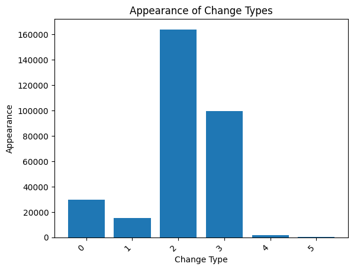

```python
import matplotlib.pyplot as plt

count_of_value = train_df['change_type'].value_counts()
labels = count_of_value.index
values = count_of_value.values

# Create bar plot
plt.bar(labels, values)

# Add labels and title
plt.xlabel('Change Type')
plt.ylabel('Appearance')
plt.title('Appearance of Change Types')

# Rotate x-axis labels for better readability
plt.xticks(rotation=45, ha='right')

# Show plot
plt.show()
```

The dataset exhibits an imbalance issue, exacerbated by certain classes having a limited number of examples. This imbalance poses a significant challenge for the model's predictive performance, particularly evident when evaluating metrics such as recall and precision for these underrepresented classes.

**Data Analysis and Feature Engineering**

In the subsequent analysis, I will investigate these hypotheses to determine whether they can serve as key features for predicting class labels.

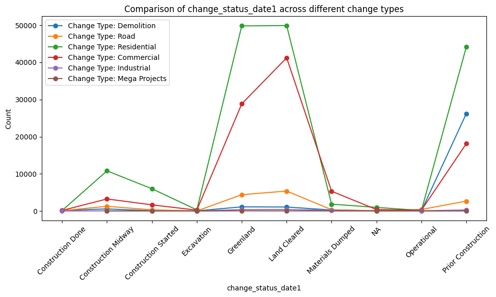

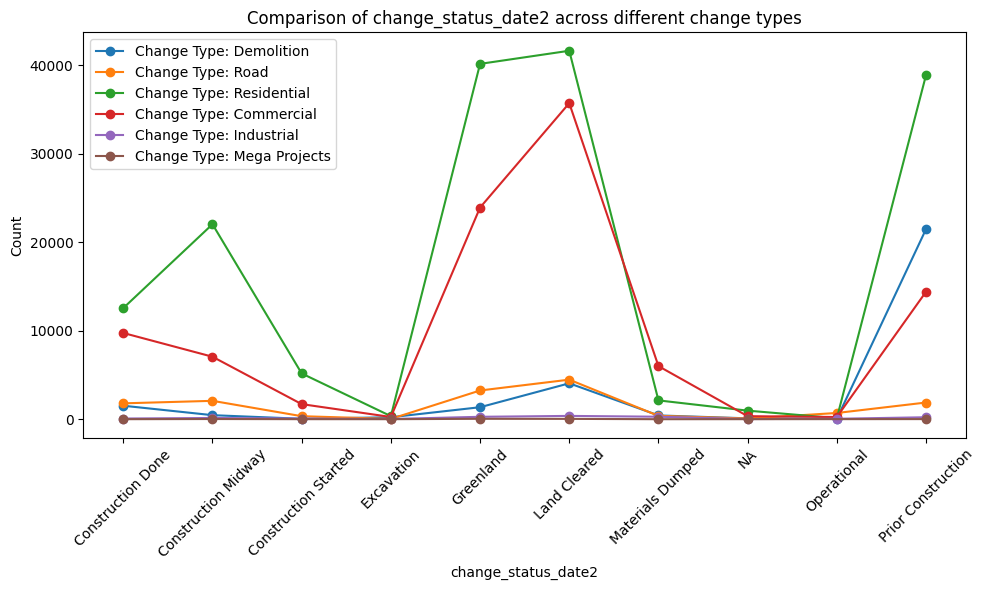

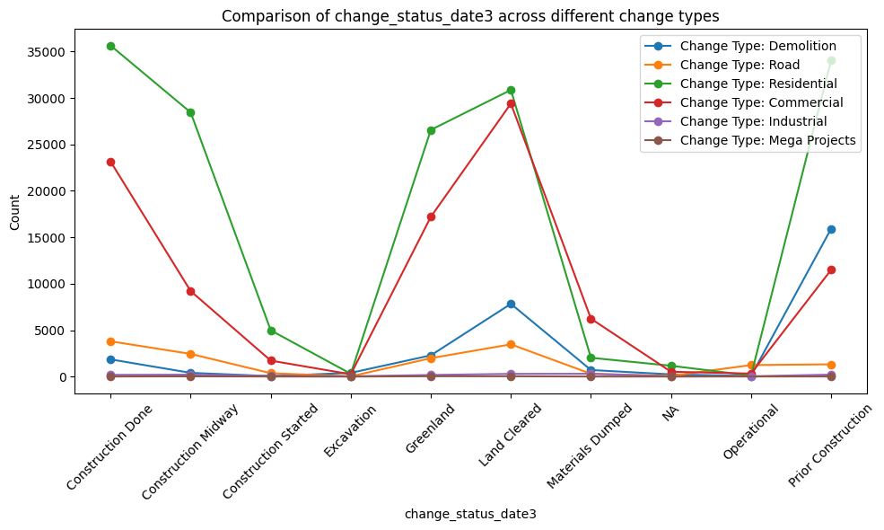

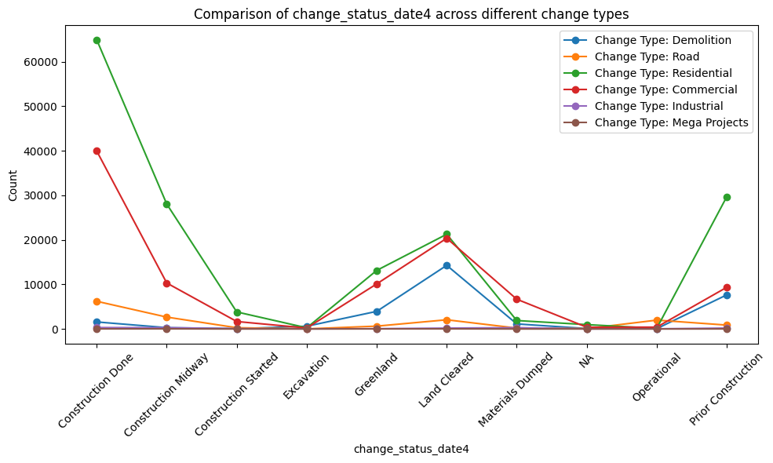

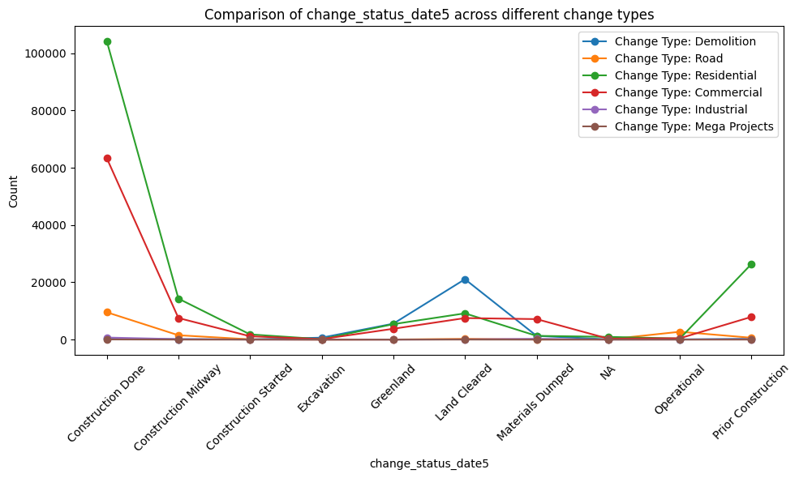

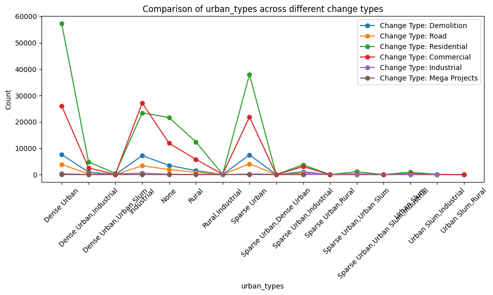

[figure not shown]

```python
import pandas as pd
import matplotlib.pyplot as plt

def plot_change_type_comparison(df, column):
    # Group the dataframe by "change_type" and the current column
    grouped = df.groupby(['change_type', column])
    # Count the occurrences of each value in the current column within each group
    counts = grouped.size().reset_index(name='count')

    # Create a separate plot for each value in "change_type"
    plt.figure(figsize=(10, 6))
    for change_type_value, group_data in counts.groupby('change_type'):
        for key, value in change_type_map.items():
            if value == change_type_value:
                change_type_value = key
        plt.plot(group_data[column], group_data['count'], marker='o', label=f'Change Type: {change_type_value}')

    plt.xlabel(column)
    plt.ylabel('Count')
    plt.title(f'Comparison of {column} across different change types')
    plt.legend()
    plt.xticks(rotation=45)
    plt.tight_layout()
    plt.show()

# List of columns to analyze
columns_to_analyze = ['change_status_date1', 'change_status_date2', 'change_status_date3',
                      'change_status_date4', 'change_status_date5', 'urban_types', 'geography_types']

# Plot comparison for each column
for column in columns_to_analyze:
    plot_change_type_comparison(train_df, column)
```

***NOTE** As observed, certain classes tend to begin or end with specific statuses. Statuses are crucial in determining the classes in this scenario, but we need to convert the columns into quantitative ones. In our case, we utilize the one-hot vector model.

```python
# Apply one-hot encoding
one_hot_encoded1 = pd.get_dummies(train_df['change_status_date1'], prefix='change_status_date1_vec', dtype=int)
one_hot_encoded2 = pd.get_dummies(train_df['change_status_date2'], prefix='change_status_date2_vec', dtype=int)
one_hot_encoded3 = pd.get_dummies(train_df['change_status_date3'], prefix='change_status_date3_vec', dtype=int)
one_hot_encoded4 = pd.get_dummies(train_df['change_status_date4'], prefix='change_status_date4_vec', dtype=int)
one_hot_encoded5 = pd.get_dummies(train_df['change_status_date5'], prefix='change_status_date5_vec', dtype=int)
one_hot_encoded6 = pd.get_dummies(train_df['urban_types'], prefix='urban_types_vec', dtype=int)
one_hot_encoded7 = pd.get_dummies(train_df['geography_types'], prefix='geography_types_vec', dtype=int)


# Concatenate the one-hot encoded columns with the original dataframe
train_df_encoded = pd.concat([train_df, one_hot_encoded1, one_hot_encoded2, one_hot_encoded3, one_hot_encoded4, one_hot_encoded5, one_hot_encoded6, one_hot_encoded7], axis=1)

train_df_encoded
```

|  | index | change_type | change_status_date1 | change_status_date2 | change_status_date3 | change_status_date4 | change_status_date5 | date1 | date2 | date3 | ... | geography_types_vec_Sparse Forest,Grass Land | geography_types_vec_Sparse Forest,Grass Land,Desert | geography_types_vec_Sparse Forest,Grass Land,Farms | geography_types_vec_Sparse Forest,Grass Land,Farms,Lakes | geography_types_vec_Sparse Forest,Grass Land,Hills | geography_types_vec_Sparse Forest,Grass Land,Hills,Lakes | geography_types_vec_Sparse Forest,Grass Land,Lakes | geography_types_vec_Sparse Forest,Grass Land,Lakes,Snow | geography_types_vec_Sparse Forest,Hills | geography_types_vec_Sparse Forest,Lakes |
| --- | --- | --- | --- | --- | --- | --- | --- | --- | --- | --- | --- | --- | --- | --- | --- | --- | --- | --- | --- | --- | --- |
| 0 | 0 | 3 | Land Cleared | Construction Midway | Construction Done | Construction Done | Construction Done | 29-05-2014 | 13-09-2015 | 25-02-2017 | ... | 0 | 0 | 0 | 0 | 0 | 0 | 0 | 0 | 0 | 0 |
| 1 | 1 | 3 | Greenland | Greenland | Construction Done | Construction Done | Construction Done | 29-05-2014 | 13-09-2015 | 25-02-2017 | ... | 1 | 0 | 0 | 0 | 0 | 0 | 0 | 0 | 0 | 0 |
| 2 | 2 | 3 | Land Cleared | Land Cleared | Construction Done | Construction Done | Construction Done | 29-05-2014 | 13-09-2015 | 25-02-2017 | ... | 1 | 0 | 0 | 0 | 0 | 0 | 0 | 0 | 0 | 0 |
| 3 | 3 | 3 | Land Cleared | Land Cleared | Construction Midway | Construction Midway | Construction Done | 29-05-2014 | 13-09-2015 | 25-02-2017 | ... | 0 | 0 | 0 | 0 | 0 | 0 | 0 | 0 | 0 | 0 |
| 4 | 4 | 3 | Land Cleared | Land Cleared | Construction Started | Construction Midway | Construction Done | 29-05-2014 | 13-09-2015 | 25-02-2017 | ... | 0 | 0 | 0 | 0 | 0 | 0 | 0 | 0 | 0 | 0 |
| ... | ... | ... | ... | ... | ... | ... | ... | ... | ... | ... | ... | ... | ... | ... | ... | ... | ... | ... | ... | ... | ... |
| 310001 | 310001 | 2 | Prior Construction | Prior Construction | Prior Construction | Land Cleared | Construction Done | 18-11-2014 | 01-03-2016 | 01-01-2018 | ... | 0 | 0 | 0 | 0 | 0 | 0 | 0 | 0 | 0 | 0 |
| 310002 | 310002 | 2 | Land Cleared | Land Cleared | Land Cleared | Land Cleared | Construction Done | 18-11-2014 | 01-03-2016 | 01-01-2018 | ... | 0 | 0 | 0 | 0 | 0 | 0 | 0 | 0 | 0 | 0 |
| 310003 | 310003 | 3 | Materials Dumped | Land Cleared | Land Cleared | Land Cleared | Construction Done | 18-11-2014 | 01-03-2016 | 01-01-2018 | ... | 0 | 0 | 0 | 0 | 0 | 0 | 0 | 0 | 0 | 0 |
| 310004 | 310004 | 3 | Land Cleared | Land Cleared | Land Cleared | Greenland | Greenland | 18-11-2014 | 01-03-2016 | 01-01-2018 | ... | 0 | 0 | 0 | 0 | 0 | 0 | 0 | 0 | 0 | 0 |
| 310005 | 310005 | 3 | Land Cleared | Land Cleared | Land Cleared | Greenland | Greenland | 18-11-2014 | 01-03-2016 | 01-01-2018 | ... | 0 | 0 | 0 | 0 | 0 | 0 | 0 | 0 | 0 | 0 |

310006 rows × 261 columns

```python
train_df_encoded['date1'] = pd.to_datetime(train_df_encoded['date1'], format='%d-%m-%Y')
train_df_encoded['date2'] = pd.to_datetime(train_df_encoded['date2'], format='%d-%m-%Y')
train_df_encoded['date3'] = pd.to_datetime(train_df_encoded['date3'], format='%d-%m-%Y')
train_df_encoded['date4'] = pd.to_datetime(train_df_encoded['date4'], format='%d-%m-%Y')
train_df_encoded['date5'] = pd.to_datetime(train_df_encoded['date5'], format='%d-%m-%Y')

train_df_encoded['area'] = train_df_encoded.geometry.area

# Calculate perimeter of polygons
train_df_encoded['perimeter'] = train_df_encoded.geometry.length



# Drop the 'geometry' column
train_df_encoded = train_df_encoded.drop(columns='geometry')
train_df_encoded
```

|  | index | change_type | change_status_date1 | change_status_date2 | change_status_date3 | change_status_date4 | change_status_date5 | date1 | date2 | date3 | ... | geography_types_vec_Sparse Forest,Grass Land,Farms | geography_types_vec_Sparse Forest,Grass Land,Farms,Lakes | geography_types_vec_Sparse Forest,Grass Land,Hills | geography_types_vec_Sparse Forest,Grass Land,Hills,Lakes | geography_types_vec_Sparse Forest,Grass Land,Lakes | geography_types_vec_Sparse Forest,Grass Land,Lakes,Snow | geography_types_vec_Sparse Forest,Hills | geography_types_vec_Sparse Forest,Lakes | area | perimeter |
| --- | --- | --- | --- | --- | --- | --- | --- | --- | --- | --- | --- | --- | --- | --- | --- | --- | --- | --- | --- | --- | --- |
| 0 | 0 | 3 | Land Cleared | Construction Midway | Construction Done | Construction Done | Construction Done | 2014-05-29 | 2015-09-13 | 2017-02-25 | ... | 0 | 0 | 0 | 0 | 0 | 0 | 0 | 0 | 1.237159e-06 | 0.005545 |
| 1 | 1 | 3 | Greenland | Greenland | Construction Done | Construction Done | Construction Done | 2014-05-29 | 2015-09-13 | 2017-02-25 | ... | 0 | 0 | 0 | 0 | 0 | 0 | 0 | 0 | 4.701495e-07 | 0.002917 |
| 2 | 2 | 3 | Land Cleared | Land Cleared | Construction Done | Construction Done | Construction Done | 2014-05-29 | 2015-09-13 | 2017-02-25 | ... | 0 | 0 | 0 | 0 | 0 | 0 | 0 | 0 | 4.536881e-07 | 0.002875 |
| 3 | 3 | 3 | Land Cleared | Land Cleared | Construction Midway | Construction Midway | Construction Done | 2014-05-29 | 2015-09-13 | 2017-02-25 | ... | 0 | 0 | 0 | 0 | 0 | 0 | 0 | 0 | 2.936349e-07 | 0.002596 |
| 4 | 4 | 3 | Land Cleared | Land Cleared | Construction Started | Construction Midway | Construction Done | 2014-05-29 | 2015-09-13 | 2017-02-25 | ... | 0 | 0 | 0 | 0 | 0 | 0 | 0 | 0 | 2.905206e-07 | 0.002606 |
| ... | ... | ... | ... | ... | ... | ... | ... | ... | ... | ... | ... | ... | ... | ... | ... | ... | ... | ... | ... | ... | ... |
| 310001 | 310001 | 2 | Prior Construction | Prior Construction | Prior Construction | Land Cleared | Construction Done | 2014-11-18 | 2016-03-01 | 2018-01-01 | ... | 0 | 0 | 0 | 0 | 0 | 0 | 0 | 0 | 1.428818e-07 | 0.001618 |
| 310002 | 310002 | 2 | Land Cleared | Land Cleared | Land Cleared | Land Cleared | Construction Done | 2014-11-18 | 2016-03-01 | 2018-01-01 | ... | 0 | 0 | 0 | 0 | 0 | 0 | 0 | 0 | 6.767191e-08 | 0.001066 |
| 310003 | 310003 | 3 | Materials Dumped | Land Cleared | Land Cleared | Land Cleared | Construction Done | 2014-11-18 | 2016-03-01 | 2018-01-01 | ... | 0 | 0 | 0 | 0 | 0 | 0 | 0 | 0 | 8.923550e-08 | 0.001276 |
| 310004 | 310004 | 3 | Land Cleared | Land Cleared | Land Cleared | Greenland | Greenland | 2014-11-18 | 2016-03-01 | 2018-01-01 | ... | 0 | 0 | 0 | 0 | 0 | 0 | 0 | 0 | 9.931494e-08 | 0.001407 |
| 310005 | 310005 | 3 | Land Cleared | Land Cleared | Land Cleared | Greenland | Greenland | 2014-11-18 | 2016-03-01 | 2018-01-01 | ... | 0 | 0 | 0 | 0 | 0 | 0 | 0 | 0 | 9.177241e-08 | 0.001362 |

310006 rows × 262 columns

```python
print(train_df_encoded.dtypes)
```

```
index                                                        int64
change_type                                                  int64
change_status_date1                                         object
change_status_date2                                         object
change_status_date3                                         object
                                                            ...
geography_types_vec_Sparse Forest,Grass Land,Lakes,Snow      int64
geography_types_vec_Sparse Forest,Hills                      int64
geography_types_vec_Sparse Forest,Lakes                      int64
area                                                       float64
perimeter                                                  float64
Length: 262, dtype: object
```

**Now**, we will proceed with the calculations required for the second hypothesis.

This code snippet defines a function `calculate_days(date1, date2)` to calculate the number of days between two dates. It first checks if either of the dates is null. If so, it returns 0. Otherwise, it computes the absolute difference in days between the two dates.

The main loop iterates through each row of the DataFrame `train_df_encoded`. For each row, it extracts lists of statuses and dates. Then, it iterates through the status list and calculates the number of days until the next status change. It updates the DataFrame with the calculated days for each pair of consecutive dates and status changes.

Here's a step-by-step breakdown of the loop:

1. It initializes a variable `days_until_change` to 0.
2. It iterates through the status list, checking for changes in consecutive statuses.
3. If there is a status change (i.e., the status at index `i` is different from the status at index `i+1`), it calculates the days between the corresponding dates using the `calculate_days` function and updates the DataFrame with the result.
4. If there is no status change, it continues accumulating the days until the next change.
5. Finally, it breaks out of the loop when reaching the last pair of dates and statuses. If needed, it calculates the days until the end and updates the DataFrame accordingly.

```python
# Fonction pour calculer le nombre de jours entre deux dates
def calculate_days(date1, date2):
    if pd.isnull(date1) or pd.isnull(date2):
        return 0
    return abs((date2 - date1).days)

# Parcours du DataFrame
for index, row in train_df_encoded.iterrows():
    status_list = [row['change_status_date1'], row['change_status_date2'], row['change_status_date3'], row['change_status_date4'], row['change_status_date5']]
    date_list = [row['date1'], row['date2'], row['date3'], row['date4'], row['date5']]

    days_until_change = 0
    for i in range(len(status_list) - 1):
        if i+1 == 4 :
            days_until_change += calculate_days(date_list[i], date_list[i+1])
            train_df_encoded.at[index, f'Days between Date{i+1} and Date{i+2}'] = days_until_change
            days_until_change = 0
            break
        elif status_list[i] != status_list[i+1]:
            days_until_change += calculate_days(date_list[i], date_list[i+1])
            train_df_encoded.at[index, f'Days between Date{i+1} and Date{i+2}'] = days_until_change
            days_until_change = 0
        else:
            days_until_change += calculate_days(date_list[i], date_list[i+1])
            train_df_encoded.at[index, f'Days between Date{i+1} and Date{i+2}'] = 0
```

```python
train_df_encoded
```

|  | index | change_type | change_status_date1 | change_status_date2 | change_status_date3 | change_status_date4 | change_status_date5 | date1 | date2 | date3 | ... | geography_types_vec_Sparse Forest,Grass Land,Lakes | geography_types_vec_Sparse Forest,Grass Land,Lakes,Snow | geography_types_vec_Sparse Forest,Hills | geography_types_vec_Sparse Forest,Lakes | area | perimeter | Days between Date1 and Date2 | Days between Date2 and Date3 | Days between Date3 and Date4 | Days between Date4 and Date5 |
| --- | --- | --- | --- | --- | --- | --- | --- | --- | --- | --- | --- | --- | --- | --- | --- | --- | --- | --- | --- | --- | --- |
| 0 | 0 | 3 | Land Cleared | Construction Midway | Construction Done | Construction Done | Construction Done | 2014-05-29 | 2015-09-13 | 2017-02-25 | ... | 0 | 0 | 0 | 0 | 1.237159e-06 | 0.005545 | 472.0 | 531.0 | 0.0 | 1179.0 |
| 1 | 1 | 3 | Greenland | Greenland | Construction Done | Construction Done | Construction Done | 2014-05-29 | 2015-09-13 | 2017-02-25 | ... | 0 | 0 | 0 | 0 | 4.701495e-07 | 0.002917 | 0.0 | 1003.0 | 0.0 | 1179.0 |
| 2 | 2 | 3 | Land Cleared | Land Cleared | Construction Done | Construction Done | Construction Done | 2014-05-29 | 2015-09-13 | 2017-02-25 | ... | 0 | 0 | 0 | 0 | 4.536881e-07 | 0.002875 | 0.0 | 1003.0 | 0.0 | 1179.0 |
| 3 | 3 | 3 | Land Cleared | Land Cleared | Construction Midway | Construction Midway | Construction Done | 2014-05-29 | 2015-09-13 | 2017-02-25 | ... | 0 | 0 | 0 | 0 | 2.936349e-07 | 0.002596 | 0.0 | 1003.0 | 0.0 | 1179.0 |
| 4 | 4 | 3 | Land Cleared | Land Cleared | Construction Started | Construction Midway | Construction Done | 2014-05-29 | 2015-09-13 | 2017-02-25 | ... | 0 | 0 | 0 | 0 | 2.905206e-07 | 0.002606 | 0.0 | 1003.0 | 592.0 | 587.0 |
| ... | ... | ... | ... | ... | ... | ... | ... | ... | ... | ... | ... | ... | ... | ... | ... | ... | ... | ... | ... | ... | ... |
| 310001 | 310001 | 2 | Prior Construction | Prior Construction | Prior Construction | Land Cleared | Construction Done | 2014-11-18 | 2016-03-01 | 2018-01-01 | ... | 0 | 0 | 0 | 0 | 1.428818e-07 | 0.001618 | 0.0 | 0.0 | 1625.0 | 336.0 |
| 310002 | 310002 | 2 | Land Cleared | Land Cleared | Land Cleared | Land Cleared | Construction Done | 2014-11-18 | 2016-03-01 | 2018-01-01 | ... | 0 | 0 | 0 | 0 | 6.767191e-08 | 0.001066 | 0.0 | 0.0 | 0.0 | 1961.0 |
| 310003 | 310003 | 3 | Materials Dumped | Land Cleared | Land Cleared | Land Cleared | Construction Done | 2014-11-18 | 2016-03-01 | 2018-01-01 | ... | 0 | 0 | 0 | 0 | 8.923550e-08 | 0.001276 | 469.0 | 0.0 | 0.0 | 1492.0 |
| 310004 | 310004 | 3 | Land Cleared | Land Cleared | Land Cleared | Greenland | Greenland | 2014-11-18 | 2016-03-01 | 2018-01-01 | ... | 0 | 0 | 0 | 0 | 9.931494e-08 | 0.001407 | 0.0 | 0.0 | 1625.0 | 336.0 |
| 310005 | 310005 | 3 | Land Cleared | Land Cleared | Land Cleared | Greenland | Greenland | 2014-11-18 | 2016-03-01 | 2018-01-01 | ... | 0 | 0 | 0 | 0 | 9.177241e-08 | 0.001362 | 0.0 | 0.0 | 1625.0 | 336.0 |

310006 rows × 266 columns

**Finally**, we will proceed with the calculations required for the third hypothesis.

```python
date_columns = ['date1', 'date2', 'date3', 'date4', 'date5']
season_map = {'Winter' : 1,'Spring' : 2, 'Summer' : 3, 'Fall': 4 }
quarter_map = {'Q1' : 1,'Q2' : 2, 'Q3' : 3, 'Q4': 4 }
# Convert dates to seasons or quarters
def get_season(month):
    if month in [12, 1, 2]:
        return season_map['Winter']
    elif month in [3, 4, 5]:
        return season_map['Spring']
    elif month in [6, 7, 8]:
        return season_map['Summer']
    else:
        return season_map['Fall']

def get_quarter(month):
    if month in range(1, 4):
        return quarter_map['Q1']
    elif month in range(4, 7):
        return quarter_map['Q2']
    elif month in range(7, 10):
        return quarter_map['Q3']
    else:
        return quarter_map['Q4']

for col in date_columns:
    month = train_df_encoded[col].dt.month
    train_df_encoded[f'Season_{col}'] = month.apply(get_season)
    train_df_encoded[f'Quarter_{col}'] = month.apply(get_quarter)
```

```python
train_df_encoded
```

|  | index | change_type | change_status_date1 | change_status_date2 | change_status_date3 | change_status_date4 | change_status_date5 | date1 | date2 | date3 | ... | Season_date1 | Quarter_date1 | Season_date2 | Quarter_date2 | Season_date3 | Quarter_date3 | Season_date4 | Quarter_date4 | Season_date5 | Quarter_date5 |
| --- | --- | --- | --- | --- | --- | --- | --- | --- | --- | --- | --- | --- | --- | --- | --- | --- | --- | --- | --- | --- | --- |
| 0 | 0 | 3 | Land Cleared | Construction Midway | Construction Done | Construction Done | Construction Done | 2014-05-29 | 2015-09-13 | 2017-02-25 | ... | 2 | 2 | 4 | 3 | 1 | 1 | 4 | 4 | 2 | 2 |
| 1 | 1 | 3 | Greenland | Greenland | Construction Done | Construction Done | Construction Done | 2014-05-29 | 2015-09-13 | 2017-02-25 | ... | 2 | 2 | 4 | 3 | 1 | 1 | 4 | 4 | 2 | 2 |
| 2 | 2 | 3 | Land Cleared | Land Cleared | Construction Done | Construction Done | Construction Done | 2014-05-29 | 2015-09-13 | 2017-02-25 | ... | 2 | 2 | 4 | 3 | 1 | 1 | 4 | 4 | 2 | 2 |
| 3 | 3 | 3 | Land Cleared | Land Cleared | Construction Midway | Construction Midway | Construction Done | 2014-05-29 | 2015-09-13 | 2017-02-25 | ... | 2 | 2 | 4 | 3 | 1 | 1 | 4 | 4 | 2 | 2 |
| 4 | 4 | 3 | Land Cleared | Land Cleared | Construction Started | Construction Midway | Construction Done | 2014-05-29 | 2015-09-13 | 2017-02-25 | ... | 2 | 2 | 4 | 3 | 1 | 1 | 4 | 4 | 2 | 2 |
| ... | ... | ... | ... | ... | ... | ... | ... | ... | ... | ... | ... | ... | ... | ... | ... | ... | ... | ... | ... | ... | ... |
| 310001 | 310001 | 2 | Prior Construction | Prior Construction | Prior Construction | Land Cleared | Construction Done | 2014-11-18 | 2016-03-01 | 2018-01-01 | ... | 4 | 4 | 2 | 1 | 1 | 1 | 2 | 2 | 2 | 2 |
| 310002 | 310002 | 2 | Land Cleared | Land Cleared | Land Cleared | Land Cleared | Construction Done | 2014-11-18 | 2016-03-01 | 2018-01-01 | ... | 4 | 4 | 2 | 1 | 1 | 1 | 2 | 2 | 2 | 2 |
| 310003 | 310003 | 3 | Materials Dumped | Land Cleared | Land Cleared | Land Cleared | Construction Done | 2014-11-18 | 2016-03-01 | 2018-01-01 | ... | 4 | 4 | 2 | 1 | 1 | 1 | 2 | 2 | 2 | 2 |
| 310004 | 310004 | 3 | Land Cleared | Land Cleared | Land Cleared | Greenland | Greenland | 2014-11-18 | 2016-03-01 | 2018-01-01 | ... | 4 | 4 | 2 | 1 | 1 | 1 | 2 | 2 | 2 | 2 |
| 310005 | 310005 | 3 | Land Cleared | Land Cleared | Land Cleared | Greenland | Greenland | 2014-11-18 | 2016-03-01 | 2018-01-01 | ... | 4 | 4 | 2 | 1 | 1 | 1 | 2 | 2 | 2 | 2 |

310006 rows × 276 columns

This visualization aims to assess the validity of the third hypothesis, indicating whether seasonal and quarterly variations have a significant impact on the final prediction. However, it appears that these factors do not have a substantial influence on the prediction outcome.

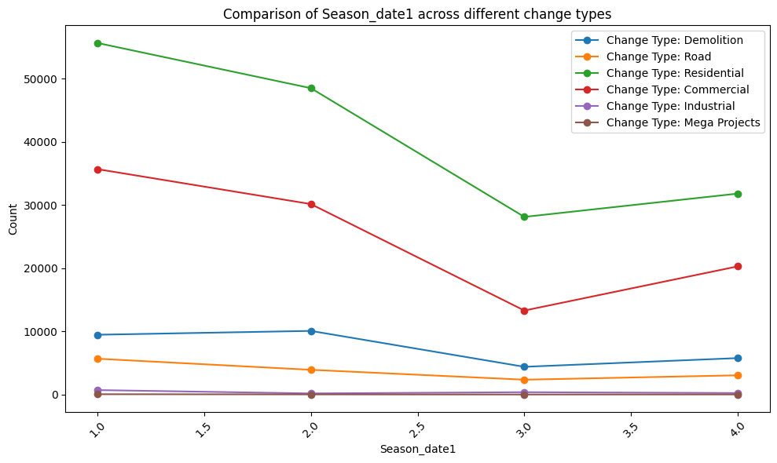

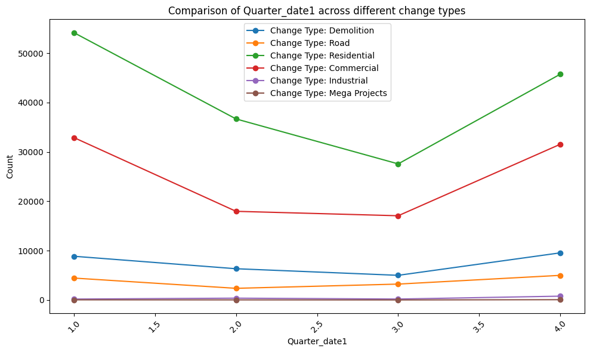

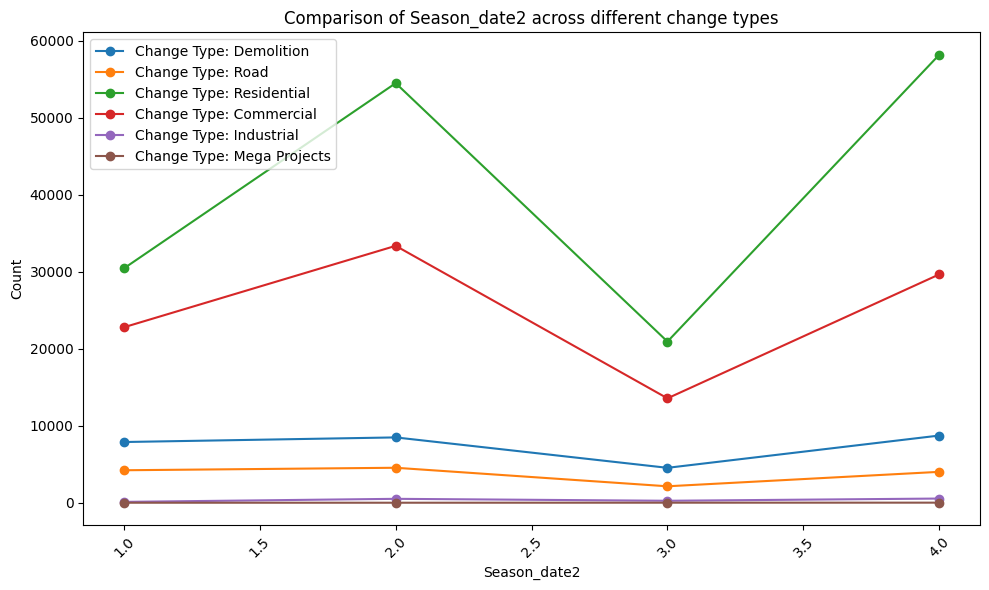

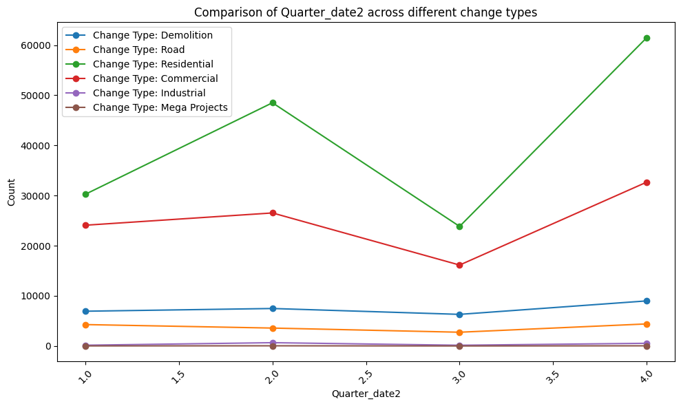

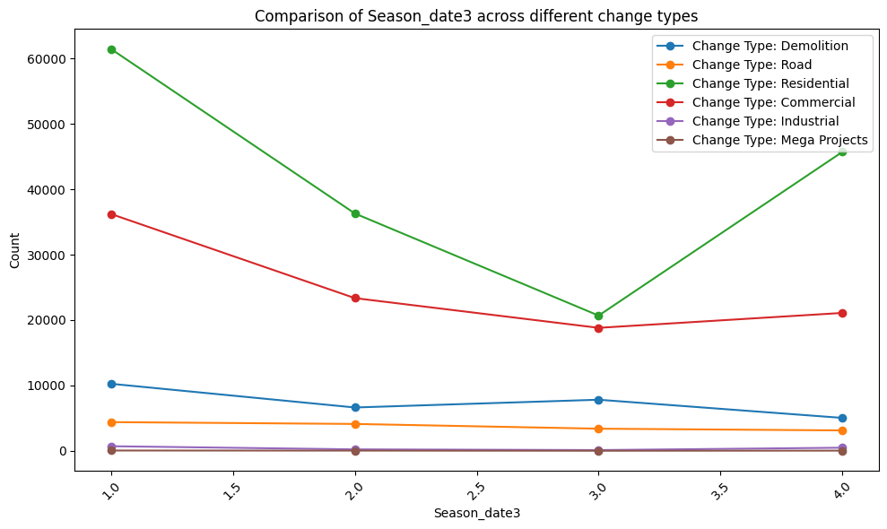

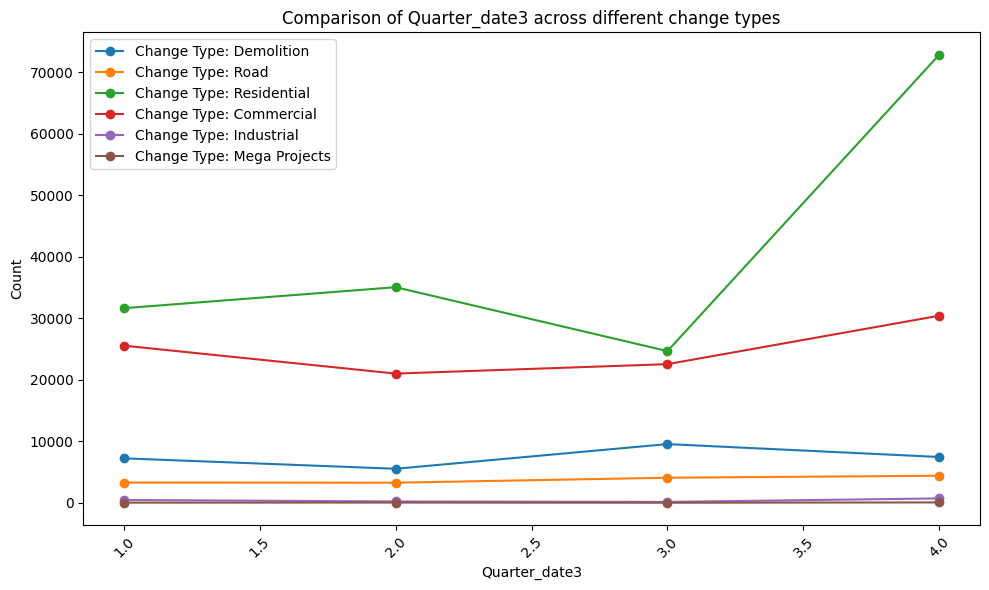

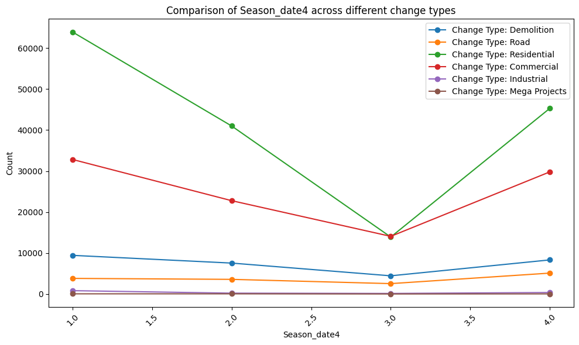

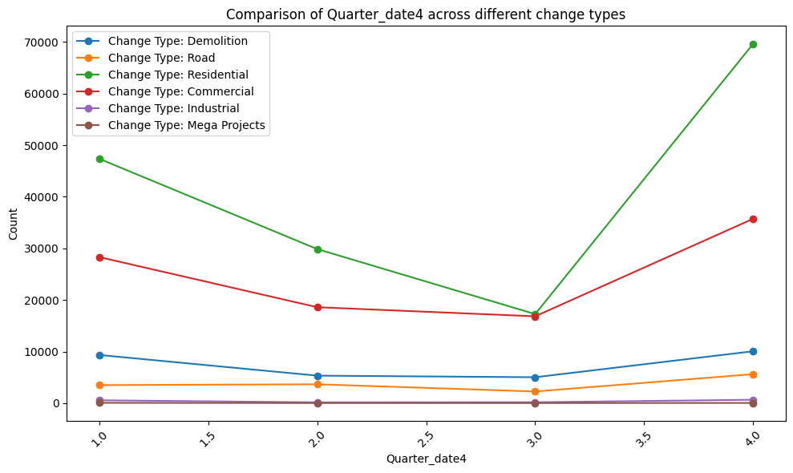

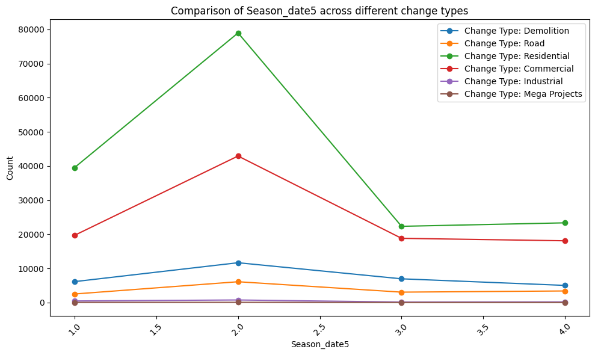

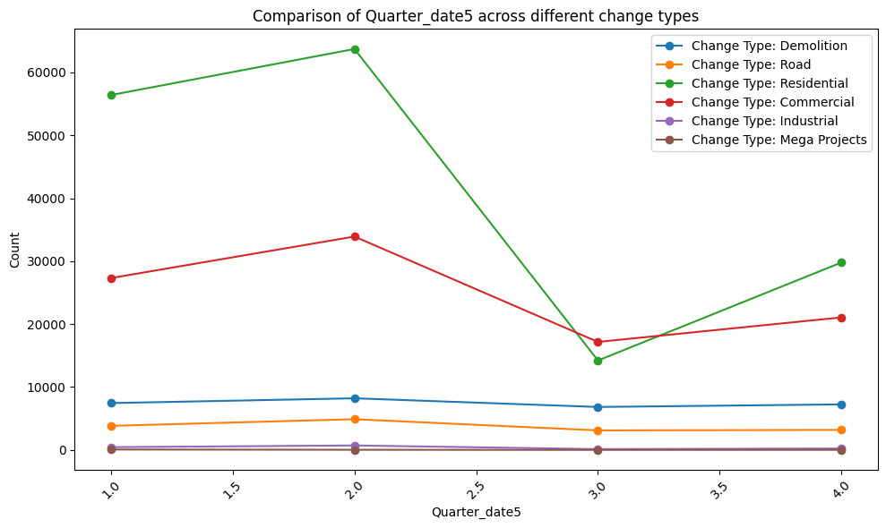

```python
# List of columns to analyze
columns_to_analyze = ['Season_date1','Quarter_date1','Season_date2','Quarter_date2','Season_date3','Quarter_date3','Season_date4','Quarter_date4','Season_date5','Quarter_date5']

# Plot comparison for each column
for column in columns_to_analyze:
    plot_change_type_comparison(train_df_encoded, column)
```

Now that we've generated new features and transformed quantitative values into qualitative ones, we will remove the original quantitative versions of the values retained for analysis and feature engineering.

```python
columns_to_drop = ['change_status_date1', 'change_status_date2', 'change_status_date3',
                   'change_status_date4', 'change_status_date5', 'urban_types', 'geography_types', 'date1', 'date2','date3', 'date4', 'date5']

train_df_encoded = train_df_encoded.drop(columns=columns_to_drop)
```

```python
print(train_df_encoded.dtypes)
```

```
index                                           int64
change_type                                     int64
change_status_date1_vec_Construction Done       int64
change_status_date1_vec_Construction Midway     int64
change_status_date1_vec_Construction Started    int64
                                                ...
Quarter_date3                                   int64
Season_date4                                    int64
Quarter_date4                                   int64
Season_date5                                    int64
Quarter_date5                                   int64
Length: 264, dtype: object
```

```python
print(train_df_encoded.columns)
```

```
Index(['index', 'change_type', 'change_status_date1_vec_Construction Done',
       'change_status_date1_vec_Construction Midway',
       'change_status_date1_vec_Construction Started',
       'change_status_date1_vec_Excavation',
       'change_status_date1_vec_Greenland',
       'change_status_date1_vec_Land Cleared',
       'change_status_date1_vec_Materials Dumped',
       'change_status_date1_vec_NA',
       ...
       'Season_date1', 'Quarter_date1', 'Season_date2', 'Quarter_date2',
       'Season_date3', 'Quarter_date3', 'Season_date4', 'Quarter_date4',
       'Season_date5', 'Quarter_date5'],
      dtype='object', length=264)
```

I intended to assess the correlation using correlation metrics, and it yielded promising results for the first and second hypotheses. I ran it earlier and confirmed its functionality, but due to time constraints, I wasn't able to rerun the entire lab. Feel free to test it further.

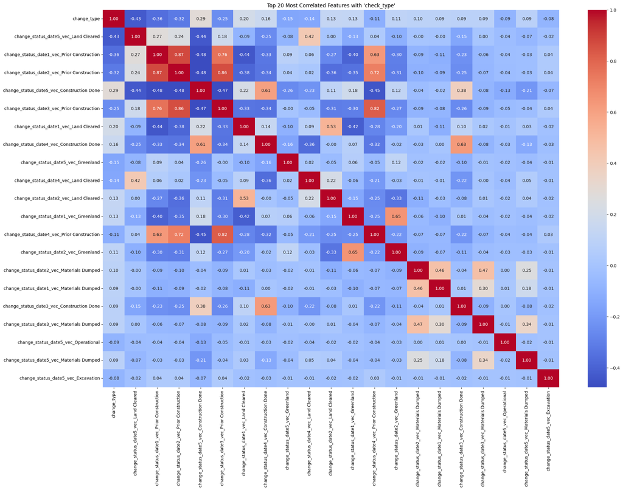

```python
import seaborn as sns

# Calculate the correlation matrix
corr_matrix = train_df_encoded.corr()

# Get the top 20 most correlated features with 'check_type'
top_corr_features = abs(corr_matrix['change_type']).sort_values(ascending=False).head(21)

# Plot the correlation matrix heatmap for the top 20 most correlated features
plt.figure(figsize=(24, 16))
sns.heatmap(train_df_encoded[top_corr_features.index].corr(), annot=True, cmap='coolwarm', fmt=".2f")
plt.title("Top 20 Most Correlated Features with 'check_type'")
plt.show()
```

**Now**, we'll prepare the data for the next step where we'll test four models: Gradient Boosting, KNN, Decision Tree, and Random Forest. Initially, we'll assess their performance by comparing F1-scores, recall, precision, accuracy, and execution time.

```python
from sklearn.model_selection import train_test_split

# Split data into training and temporary data
X_train, X_test, y_train, y_test = train_test_split(train_df_encoded.drop('change_type', axis=1), train_df_encoded['change_type'], test_size=0.2, random_state=42)

# Optionally, you can print the shapes of the resulting datasets to verify the splits
print("Training set shapes:", X_train.shape, y_train.shape)
print("Testing set shapes:", X_test.shape, y_test.shape)
```

```
Training set shapes: (248004, 263) (248004,)
Testing set shapes: (62002, 263) (62002,)
```

```python
# Check if X_train and y_train are not None
if X_train is not None and y_train is not None:
    print("X_train and y_train are not None.")

    # Check for Null Values in X_train
    if X_train.isnull().sum().sum() == 0:
        print("No Null Values found in X_train.")
    else:
        print("Null Values found in X_train.")

    # Check for Null Values in y_train
    if y_train.isnull().sum() == 0:
        print("No Null Values found in y_train.")
    else:
        print("Null Values found in y_train.")
else:
    print("X_train or y_train is None.")
```

```
X_train and y_train are not None.
No Null Values found in X_train.
No Null Values found in y_train.
```

**Models**

****Random Forest****

**Note :** This cell conducts a grid search to determine the optimal combination of hyperparameters. However, due to its time-consuming nature, we won't be executing it in this Colab. Nevertheless, feel free to run it independently. If you choose to do so, remember to uncomment the subsequent cell to ensure that you're working with the best hyperparameter settings.

```python
from sklearn.ensemble import RandomForestClassifier
from sklearn.model_selection import GridSearchCV

rf = RandomForestClassifier(n_estimators=100)
param_grid = {
    'max_depth': range(4, 8),
    'max_leaf_nodes': range(8, 12),
    'max_features': ['sqrt', 'log2']
}

rf_cv = GridSearchCV(estimator=rf,
                     param_grid=param_grid,
                     cv=5)
rf_cv.fit(X_train, y_train)
print(rf_cv.best_params_)
```

```python
#import time

## Define the parameters to use in the RandomForestClassifier
#best_params = rf_cv.best_params_

## Start timing
#start_time = time.time()

## Create the RandomForestClassifier with the best parameters
#rf = RandomForestClassifier(**best_params, bootstrap=True, oob_score=True)

## Fit the model to the training data
#rf.fit(X_train, y_train)

## Calculate the time taken for training
#rf_time = time.time() - start_time

## Print the time taken
#print("--- %s seconds ---" % (time.time() - start_time))
```

```python
from sklearn.ensemble import RandomForestClassifier
from sklearn.model_selection import GridSearchCV
import time
start_time = time.time()

rf = RandomForestClassifier(n_estimators=100, max_depth=5,
                            max_leaf_nodes=11, max_features='log2',
                            bootstrap=True, oob_score=True)
rf.fit(X_train, y_train)

rf_time = time.time() - start_time
print("--- %s seconds ---" % (time.time() - start_time))
```

```
--- 36.613588094711304 seconds ---
```

```
Feature importance of Random Forest Model
```

[figure not shown]

```python
# Check feature importance and display in bar plot.
print('Feature importance of Random Forest Model')
plt.style.use('ggplot')
fig = plt.figure(figsize=(5, 5))
feat_importances = pd.Series(rf.feature_importances_, index=X_train.columns)
feat_importances.nsmallest(5).plot(kind='barh', alpha=0.7)
fig.savefig('rf_feature.png')
```

```python
y_rf_pred = rf.predict(X_test)
```

```python
from sklearn.metrics import accuracy_score, f1_score

# Calculate accuracy score
accuracy = accuracy_score(y_test, y_rf_pred)
print("Accuracy:", accuracy)

# Calculate F1-score
f1 = f1_score(y_test, y_rf_pred, average='macro')  # 'macro' calculates F1-score for each class and averages them
print("F1-score:", f1)
```

```
Accuracy: 0.54448243605045
F1-score: 0.13187173130431815
```

```python
from sklearn.metrics import classification_report

print('Classification Report of Random Forest Model')
print(classification_report(y_test, y_rf_pred))
```

```
Classification Report of Random Forest Model
              precision    recall  f1-score   support

           0       0.00      0.00      0.00      6079
           1       0.00      0.00      0.00      2996
           2       0.54      1.00      0.70     32912
           3       0.80      0.05      0.09     19663
           4       0.00      0.00      0.00       322
           5       0.00      0.00      0.00        30

    accuracy                           0.54     62002
   macro avg       0.22      0.17      0.13     62002
weighted avg       0.54      0.54      0.40     62002
```

****KNN****

**Note :** This cell conducts a grid search to determine the optimal combination of hyperparameters. However, due to its time-consuming nature, we won't be executing it in this Colab. Nevertheless, feel free to run it independently. If you choose to do so, remember to uncomment the subsequent cell to ensure that you're working with the best hyperparameter settings.

```python
from sklearn.model_selection import GridSearchCV
from sklearn.neighbors import KNeighborsClassifier

# Define the parameter grid
param_grid = {
    'n_neighbors': [3, 5, 7, 9]
}

# Create the KNeighborsClassifier instance
neigh = KNeighborsClassifier()

# Create GridSearchCV instance
neigh_cv = GridSearchCV(estimator=neigh, param_grid=param_grid, cv=5)

# Fit the model to the data
neigh_cv.fit(X_train, y_train)

# Print the best parameters found
print(neigh_cv.best_params_)
```

```python
## Define the parameter grid
#param_grid = {'n_neighbors': [3, 5, 7, 9]}

## Create the KNeighborsClassifier instance
#neigh = KNeighborsClassifier()

## Create GridSearchCV instance
#neigh_cv = GridSearchCV(estimator=neigh, param_grid=param_grid, cv=5)

## Fit the model to the data
#neigh_cv.fit(X_train, y_train)

## Print the best parameters found
#print(neigh_cv.best_params_)
```

```python
from sklearn.ensemble import RandomForestClassifier
from sklearn.model_selection import GridSearchCV
import time
start_time = time.time()
neigh = KNeighborsClassifier(n_neighbors=9)
neigh.fit(X_train, y_train)

neigh_time = time.time() - start_time
print("--- %s seconds ---" % (time.time() - start_time))
```

```
--- 0.617485523223877 seconds ---
```

```python
pred_y = neigh.predict(X_test)
```

```python
from sklearn.metrics import accuracy_score, f1_score

# Calculate accuracy score
accuracy = accuracy_score(y_test, pred_y)
print("Accuracy:", accuracy)

# Calculate F1-score
f1 = f1_score(y_test, pred_y, average='macro')  # 'macro' calculates F1-score for each class and averages them
print("F1-score:", f1)
```

```
Accuracy: 0.6773813747943614
F1-score: 0.41830440352165144
```

```python
print('Classification Report of the KNN')
print(classification_report(y_test, pred_y))
```

```
Classification Report of the KNN
              precision    recall  f1-score   support

           0       0.57      0.56      0.57      6079
           1       0.44      0.30      0.36      2996
           2       0.75      0.80      0.77     32912
           3       0.60      0.58      0.59     19663
           4       0.06      0.00      0.01       322
           5       0.57      0.13      0.22        30

    accuracy                           0.68     62002
   macro avg       0.50      0.40      0.42     62002
weighted avg       0.67      0.68      0.67     62002
```

****Decision Tree****

**Note :** This cell conducts a grid search to determine the optimal combination of hyperparameters. However, due to its time-consuming nature, we won't be executing it in this Colab. Nevertheless, feel free to run it independently. If you choose to do so, remember to uncomment the subsequent cell to ensure that you're working with the best hyperparameter settings.

```python
from sklearn import tree
from sklearn.model_selection import GridSearchCV

# hyperparameter tuning
dt = tree.DecisionTreeClassifier()
param_grid = {
    'criterion': ['gini', 'entropy'],
    'max_depth': range(2, 8),
    'max_leaf_nodes': range(10, 20),
    'min_samples_split': range(2, 8)
}

dt_cv = GridSearchCV(estimator=dt,
                     param_grid=param_grid,
                     cv=5)
dt_cv.fit(X_train, y_train)
print(dt_cv.best_params_)
```

```python
## Instantiate the DecisionTreeClassifier with the best parameters found
#kwargs_best_params = dt_cv.best_params_
#dt = tree.DecisionTreeClassifier(**kwargs_best_params)

## Fit the model to the data
#start_time = time.time()
#dt.fit(X_train, y_train)

#dt_time = time.time() - start_time
#print("--- %s seconds ---" % (time.time() - start_time))
```

```python
from sklearn import tree
from sklearn.model_selection import GridSearchCV

# fit the model
# Decision Tree
start_time = time.time()
kwargs_regularize = dict(criterion='gini',
                         max_depth=5,
                         max_leaf_nodes=14,
                         min_samples_split=2)
dt = tree.DecisionTreeClassifier(**kwargs_regularize)
dt.fit(X_train, y_train)

dt_time = time.time() - start_time
print("--- %s seconds ---" % (time.time() - start_time))
```

```
--- 4.527324676513672 seconds ---
```

```
Feature importance of Decision Tree Model
```

[figure not shown]

```python
# Check feature importance and display in bar plot.
print('Feature importance of Decision Tree Model')
plt.style.use('ggplot')
fig = plt.figure(figsize=(5, 5))
feat_importances = pd.Series(dt.feature_importances_, index=X_train.columns)
feat_importances.nsmallest(5).plot(kind='barh', alpha=0.7)
fig.savefig('dt_feature.png')
```

```python
y_dt_pred = dt.predict(X_test)

# Calculate accuracy score
accuracy = accuracy_score(y_test, y_dt_pred)
print("Accuracy:", accuracy)

# Calculate F1-score
f1 = f1_score(y_test, y_dt_pred, average='macro')  # 'macro' calculates F1-score for each class and averages them
print("F1-score:", f1)
```

```
Accuracy: 0.6553659559369053
F1-score: 0.3839635477509821
```

```python
print('Classification Report of Random Forest Model')
print(classification_report(y_test, y_dt_pred))
```

```
Classification Report of Random Forest Model
              precision    recall  f1-score   support

           0       0.74      0.86      0.80      6079
           1       0.87      0.17      0.28      2996
           2       0.70      0.79      0.74     32912
           3       0.51      0.45      0.48     19663
           4       0.00      0.00      0.00       322
           5       0.00      0.00      0.00        30

    accuracy                           0.66     62002
   macro avg       0.47      0.38      0.38     62002
weighted avg       0.65      0.66      0.64     62002
```

****Gradient boosting****

**Note :** This cell conducts a grid search to determine the optimal combination of hyperparameters. However, due to its time-consuming nature, we won't be executing it in this Colab. Nevertheless, feel free to run it independently. If you choose to do so, remember to uncomment the subsequent cell to ensure that you're working with the best hyperparameter settings.

```python
from sklearn.ensemble import GradientBoostingClassifier
from sklearn.model_selection import GridSearchCV

gb = GradientBoostingClassifier(n_estimators=10)
param_grid = {
    'max_depth': range(2, 8),
    'max_leaf_nodes': range(8, 12)
}

gb_cv = GridSearchCV(estimator=gb,
                     param_grid=param_grid,
                     cv=5)
gb_cv.fit(X_train, y_train)
print(gb_cv.best_params_)
```

```python
## Instantiate the GradientBoostingClassifier with the best parameters found
#kwargs_best_params = gb_cv.best_params_
#gb = GradientBoostingClassifier(**kwargs_best_params)

## Fit the model to the data
#start_time = time.time()
#gb.fit(X_train, y_train)

#gb_time = time.time() - start_time
#print("--- %s seconds ---" % (time.time() - start_time))
```

```python
from sklearn.ensemble import GradientBoostingClassifier
from sklearn.model_selection import GridSearchCV
start_time = time.time()

gb = GradientBoostingClassifier(n_estimators=100, max_depth=5, max_features='sqrt',
                                max_leaf_nodes=9)
gb.fit(X_train, y_train)

gb_time = time.time() - start_time
print("--- %s seconds ---" % (time.time() - start_time))
```

```
--- 158.9305386543274 seconds ---
```

```
Feature importance of Gradient Boosting Model
```

[figure not shown]

```python
# Check feature importance and display in bar plot.
print('Feature importance of Gradient Boosting Model')
fig = plt.figure(figsize=(5, 5))
feat_importances = pd.Series(gb.feature_importances_, index=X_train.columns)
feat_importances.nsmallest(5).plot(kind='barh', alpha=0.7)
fig.savefig('gb_feature.png')
```

```python
y_gb_pred = gb.predict(X_test)
# Calculate accuracy score
accuracy = accuracy_score(y_test, y_gb_pred)
print("Accuracy:", accuracy)

# Calculate F1-score
f1 = f1_score(y_test, y_gb_pred, average='macro')  # 'macro' calculates F1-score for each class and averages them
print("F1-score:", f1)
```

```
Accuracy: 0.6984290829328086
F1-score: 0.45119766260409166
```

```python
print('Classification Report of the Gradient boosting')
print(classification_report(y_test, y_gb_pred))
```

```
Classification Report of the Gradient boosting
              precision    recall  f1-score   support

           0       0.77      0.88      0.82      6079
           1       0.71      0.31      0.43      2996
           2       0.72      0.84      0.78     32912
           3       0.61      0.48      0.54     19663
           4       0.29      0.03      0.06       322
           5       0.14      0.07      0.09        30

    accuracy                           0.70     62002
   macro avg       0.54      0.43      0.45     62002
weighted avg       0.69      0.70      0.68     62002
```

**Important** :

The model performs poorly on the 4th and 5th classes due to the limited number of examples compared to classes 0 and 2. This indicates a need for data augmentation or additional data collection to improve model performance. This observation holds true across all models.

**Models Comparison**

```python
from sklearn import metrics

dt_metrics = [
    metrics.accuracy_score(y_test, y_dt_pred),
    metrics.precision_score(y_test, y_dt_pred, average='macro'),
    metrics.recall_score(y_test, y_dt_pred, average='macro'),
    metrics.f1_score(y_test, y_dt_pred, average='macro'),
    dt_time
]

rf_metrics = [
    metrics.accuracy_score(y_test, y_rf_pred),
    metrics.precision_score(y_test, y_rf_pred, average='macro'),
    metrics.recall_score(y_test, y_rf_pred, average='macro'),
    metrics.f1_score(y_test, y_rf_pred, average='macro'),
    rf_time
]

gb_metrics = [
    metrics.accuracy_score(y_test, y_gb_pred),
    metrics.precision_score(y_test, y_gb_pred, average='macro'),
    metrics.recall_score(y_test, y_gb_pred, average='macro'),
    metrics.f1_score(y_test, y_gb_pred, average='macro'),
    gb_time
]

neigh_metrics = [
    metrics.accuracy_score(y_test, pred_y),
    metrics.precision_score(y_test, pred_y, average='macro'),
    metrics.recall_score(y_test, pred_y, average='macro'),
    metrics.f1_score(y_test, pred_y, average='macro'),
    neigh_time
]
```

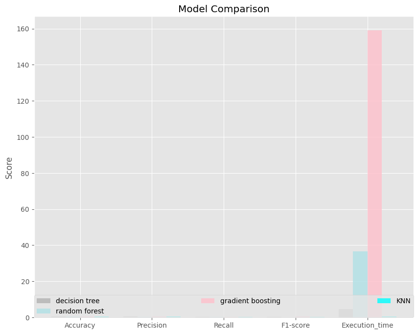

```python
fig, ax = plt.subplots(figsize=(10, 8))
index = np.arange(5)
width = 0.2
b1 = plt.bar(index, dt_metrics[0:5], width,
             alpha=0.4, color='grey', label='decision tree')
b2 = plt.bar(index+width, rf_metrics[0:5], width,
             alpha=0.8, color='powderblue', label='random forest')
b3 = plt.bar(index+2*width, gb_metrics[0:5], width,
             alpha=0.8, color='pink', label='gradient boosting')
b4 = plt.bar(index+3*width, neigh_metrics[0:5], width,
             alpha=0.8, color='cyan', label='KNN')

plt.title('Model Comparison')
plt.ylabel('Score')
plt.xticks(index+width*1.5, ('Accuracy', 'Precision', 'Recall', 'F1-score',"Execution_time"))
plt.legend(loc=8, ncol=3, mode="expand", borderaxespad=0.)
plt.show()
fig.savefig('model_comparison.png')
```

```python
import pandas as pd

# Create a DataFrame to store the metrics
model_metrics_df = pd.DataFrame({
    'Model': ['Decision Tree', 'Random Forest', 'Gradient Boosting', 'KNN'],
    'Accuracy': [dt_metrics[0], rf_metrics[0], gb_metrics[0], neigh_metrics[0]],
    'Precision': [dt_metrics[1], rf_metrics[1], gb_metrics[1], neigh_metrics[1]],
    'Recall': [dt_metrics[2], rf_metrics[2], gb_metrics[2], neigh_metrics[2]],
    'F1-score': [dt_metrics[3], rf_metrics[3], gb_metrics[3], neigh_metrics[3]],
    'Execution_time': [dt_metrics[4], rf_metrics[4], gb_metrics[4], neigh_metrics[4]]
})

# Display the DataFrame
print(model_metrics_df)
```

```
               Model  Accuracy  Precision    Recall  F1-score  Execution_time
0      Decision Tree  0.655366   0.470879  0.378442  0.383964        4.527254
1      Random Forest  0.544482   0.223083  0.174197  0.131872       36.613521
2  Gradient Boosting  0.698429   0.539727  0.434210  0.451198      158.930467
3                KNN  0.677381   0.499175  0.395688  0.418304        0.617419
```

**Conclusion**

In conclusion, our analysis and feature engineering efforts revealed several insights and hypotheses regarding the dataset and its potential impact on model performance. We identified three key hypotheses:

1. The sequential nature of status changes within the classes may play a significant role in classification.
2. The time taken for a class to transition between statuses could provide valuable information for classification.
3. Seasonal and quarterly variations in image capture might influence land use changes.

We conducted various analyses to verify these hypotheses, including data visualization, correlation analysis, and feature engineering. While some hypotheses showed promise, others did not significantly affect model performance. Additionally, we observed imbalanced data distribution across classes, which negatively impacted model performance, particularly for classes with fewer examples.

Moving forward, we plan to evaluate four models—Gradient Boosting, KNN, Decision Tree, and Random Forest—using performance metrics such as F1-score, recall, precision, accuracy, and execution time. The analysis will help identify the most suitable model and guide future steps, which may include data augmentation or collection efforts to address class imbalance and improve overall model performance.

Ultimately, our evaluation of the models revealed varying degrees of success. Classes with ample examples tended to yield higher prediction scores across the metrics, indicating better model performance. However, classes with fewer examples consistently showed poorer predictions, highlighting the challenges posed by class imbalance.

This disparity underscores the importance of addressing data imbalances in future iterations of the model. Strategies such as data augmentation, oversampling, or collecting additional examples for underrepresented classes could help mitigate these issues and improve overall prediction accuracy.

In summary, while our models demonstrated promise in certain scenarios, there remains room for improvement, particularly in handling imbalanced data distributions. By addressing these challenges and refining our approach, we can build more robust models capable of accurately predicting land use changes across all classes.